# Race and Income Inequality in Lake County, Indiana

Christopher Brodsky

## Introduction

Lake County, Indiana, situated along the border with Illinois and directly adjacent to Chicago, offers an interesting case study of income inequality along racial lines. Although a white majority state, Indiana has a substantial black population: sixty-two percent of which is contained in only two counties, Marion and Lake County (Strange, 2013). The following graphs and analyses examine three indicators of income distribution within a racialized framework, and offer a complex look at how income inequality is represented in Lake County, Indiana. Ultimately, the data shows how different representations of affluence can be contradictory and suggests that dissecting the dynamics of income inequality is hardly straightforward.

## Graph 1

The first graph looks at age and racial dynamics in the context of commuting. The pink box captures the majority of both white and black youths who commute to work by car. The legend on the right of the graph indicates light-blue dots are predominantly white census census-tracts, while the black dots represent predominantly black-majority tracts. A clear majority of white and black-majority tracts are clustered above the ninety-percent mark among commuters who use a car. The seventeen and under population includes students, part-time job holders, and youths lacking or only possessing a high school diploma. Commuting by car is generally considered a sign of affluence compared to the use of public transportation, for example. That a clear majority of this age group, regardless of racial distinction, commutes by car is a potential indicator of a narrow income inequality along racial lines in Lake County.

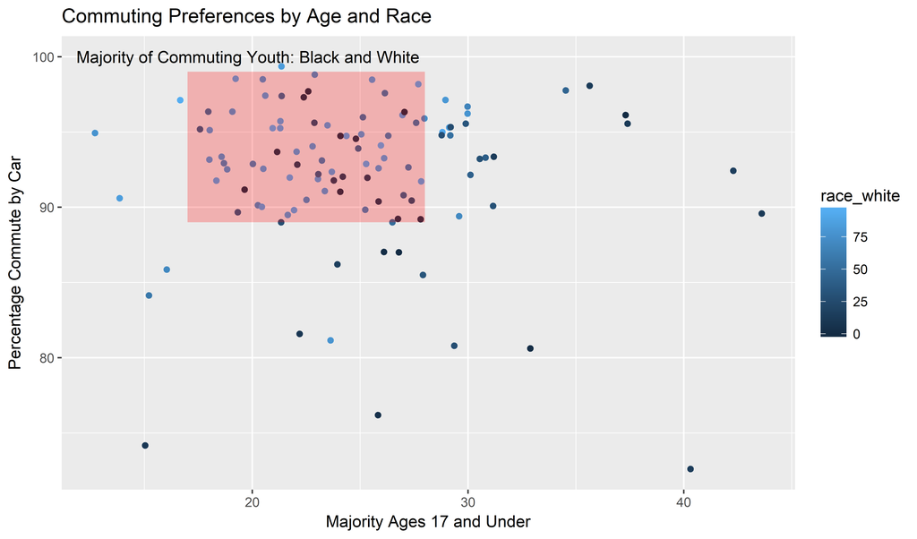

According to data from Statistical Atlas, Lake County’s youth population is almost evenly split along racial lines. In the ten-fourteen and fifteen-seventeen age cohorts, white residents account for forty-four and forty-five percent respectively. In those same age categories, black youth residents in Lake County make up twenty-nine and thirty percent respectively. Although there is a noteworthy gap between the number of white and black youth in Lake County, the discrepancy is far smaller compared with older age ranges. For example, the fifty-five to sixty-four age cohort is composed of sixty-four percent of white residents and twenty-three percent of black residents (Statistical Atlas). Thus, demographic changes may slowly be trending toward greater racial equality in Lake County.

## Graph 2

The following graph examines income and race in Lake County. Unlike the previous chart, however, this graphic illustrates distinct income inequality along racial lines. The top left pink square captures most black-majority census tracts, colored in purple, of Lake County. The location of the purple dots clustered in the top left indicates that well over seventy percent of black-majority communities earn fifty-thousand or less in income. The cluster’s location on the far left of the graph likewise demonstrates the relatively small populations of each black-majority tract.

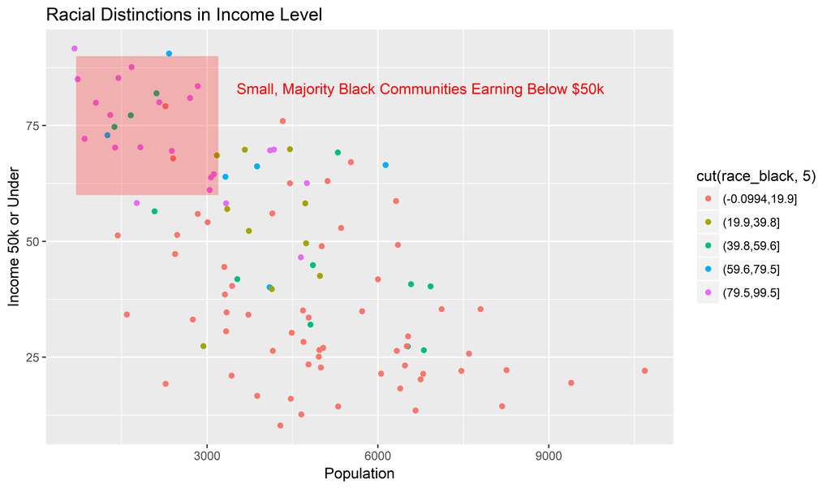

The orange dots indicate tracts with relatively small black populations. These dots are far more dispersed within the graph and indicate a larger percentage of white residents in Lake County enjoy higher annual incomes. Further, the orange dots demonstrate how populations with smaller black communities are relatively larger in population. These first two graphs illustrate the complexities of determining overall inequality in Lake County. The final graph below further complicates the picture by analyzing portions of income spent on rent.

## Graph 3

The graph below introduces an interesting caveat to the clear demonstration of income inequality shown in graph 2. The blue dots at the top of the graph represent populations which spend generally sixty percent or more of income on rent. As opposed to the lowest spenders of income on rent (the orange dots), the higher spenders are dispersed among populations with varying degrees of black-majority populations. Whereas those who spend relatively little income on rent have black populations of approximately fifteen percent or less, higher spenders (both blue and green dots) are evenly distributed across the width of the graph regardless of racial composition.

The graph suggests there is little if any racial dynamic affecting populations who spend considerable portions of income on rent. Populations spending between sixty and eighty percent of income on rent are seemingly unaffected by whether a particular tract is composed of fifteen or ninety percent of black residents. This trend holds true for the middle range of spenders of income on rent, as represented by the green dots.

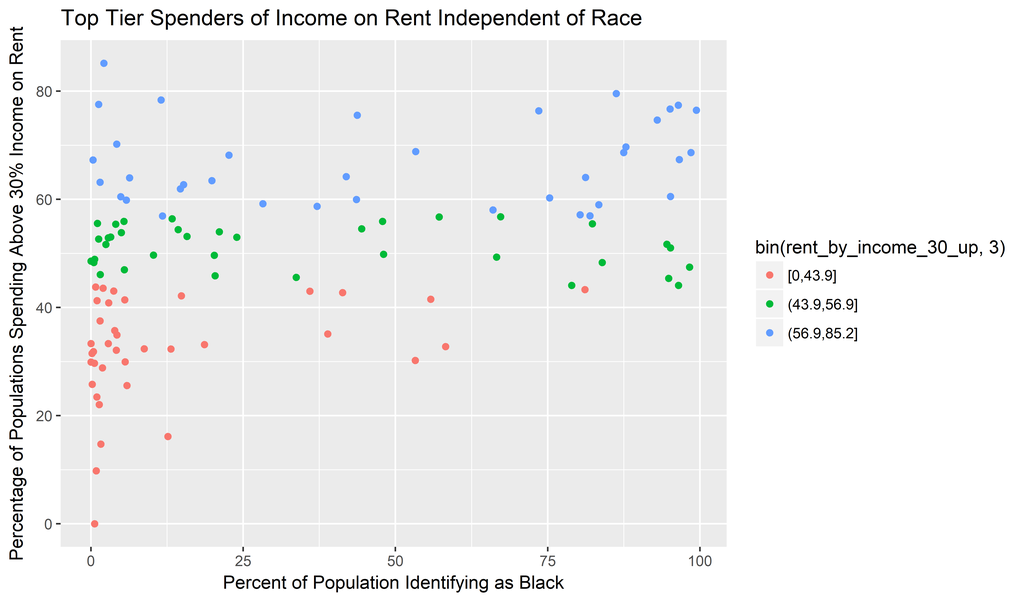

An important distinction, however, is found when examining the orange dots on the graph. These dots represent populations who spend the smallest percentage of income on rent. A clear majority of orange dots are found clustered toward the left of the graph. The location of the orange dots indicates that populations with the least percentage of black residents spend relatively less on rent than populations with larger black populations. Race, therefore, seems to play a significant role in determining which populations retain most of their wealth (in this case, white majority communities). For poorer communities, or those spending the most on rent, race appears to be less of a determining factor. In this regard, the income inequality illustrated in graph 2 is more clearly demonstrated by the predominance of white-majority communities paying a smaller share of income on rent compared to black-majority communities.

## Conclusion

The three graphs illustrate the complexities of examining income inequality in Lake County, Indiana. Although both white and black youths appear to have equal access to cars for daily commuting, generally a sign of relative wealth, the distribution of lower income-earning populations disproportionately affects black-majority communities. Likewise, relatively wealthy populations not spending large portions of income on rent are disproportionately white. Interestingly, however, race seems to play less of a role in poorer communities, or those spending the most of their income on rent. In combination, these graphs paint a complex and, at times, contradictory picture of wealth and inequality in Lake County.

# References

http://www.incontext.indiana.edu/2013/may-jun/article3.asp

https://statisticalatlas.com/county/Indiana/Lake-County/Race-and-Ethnicity